# Assignment 9

Mario Perales

April 6, 2016

*Source file* ⇒ assignment9.Rmd

# Part 1

We must first load up the data.

```r
library(rvest)
library(lubridate)
page <- "http://en.wikipedia.org/wiki/List_of_nuclear_reactors"
xpath <- '//*[@id="mw-content-text"]/table'
table_list <- page %>%
  read_html() %>%
  html_nodes(xpath = xpath) %>%
  html_table(fill = TRUE)
```

We find that the Japanese portion is found as the 23rd element of our `table_list`. Looking at the names, we see that the subsections of capacity are broken individually. Thus, we fix the names (i.e. columns) of `table` to better reflect the data found on the Wikipedia page.

```r
table = table_list[[23]]
names(table) <- c("Name", "Reactor_No.", "Reactor_Type", "Reactor_Model", "Status", "Capacity_in_MW_Net", "Capicity_in_MW, Gross", "Construction_Start_Date", "Commercial_Operation_Date", "Closure")

table <- table %>% filter(row_number() != 1) # drop the first row
```

We then convert all the *dates* in our `table` into a readable format using `dmy`.

Finally, we plot the data.

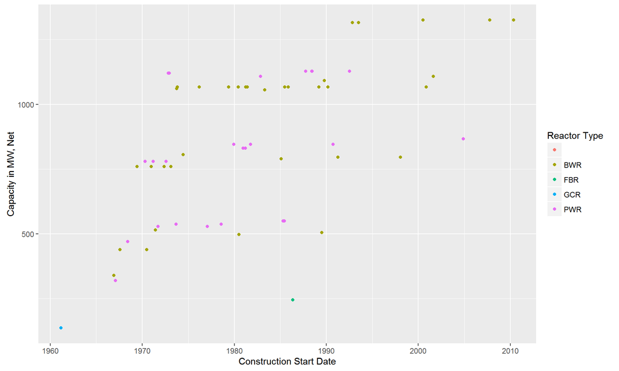

```r
table$Construction_Start_Date = dmy(table$Construction_Start_Date)
table$Commercial_Operation_Date = dmy(table$Commercial_Operation_Date)
table$Closure = dmy(table$Closure)

table %>%
  ggplot(aes(x = Construction_Start_Date, y = Capacity_in_MW_Net)) +
  geom_point(aes(color = Reactor_Type)) +
  ylab("Capacity in MW, Net") +
  xlab("Construction Start Date") +
  labs(color = "Reactor Type")
```

We first change the `name` column in our `table` to append the corresponding Reactor No. to the Reactor name to differentiate each Reactor.

After this, we plot the data and label the `y_ticks` in such a way that only the names of Reactors with Reactor No. = 1. We do this by using a `labels` vector. Overall, we end up with the following graph:

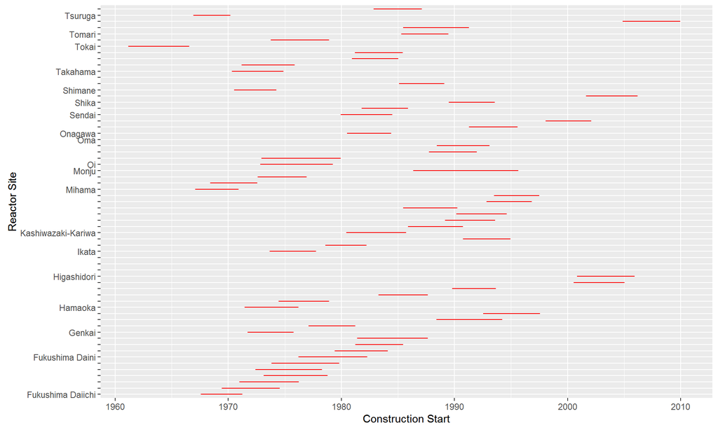

```r
table <-
  table %>%
  mutate(Name = paste(table$Name, table$Reactor_No.))


table %>%
  ggplot(aes(x = Construction_Start_Date, y = Name)) +
  geom_segment(aes(x = Construction_Start_Date, y = Name, xend = Commercial_Operation_Date, yend = Name), color = "red") +
  scale_y_discrete(limit = table$Name,
                   labels = c("Fukushima Daiichi", "","","","","","Fukushima Daini","","","","Genkai","","","","Hamaoka","","","","","Higashidori","","","","Ikata","","","Kashiwazaki-Kariwa","","","","","","","Mihama","","","Monju","Oi","","","","Oma","Onagawa","","","Sendai","","Shika","","Shimane","","","Takahama","","","","Tokai","","Tomari","","","Tsuruga","")) +
  ylab("Reactor Site") +
  xlab("Construction Start")
```

# Part 2

Note that since I am using a PC, I must use the Windows Powershell to move the downloaded files from my desktop to ~/MyDataScienceToolbox/. I indicate such steps when necessary.

## 1

UNIX:

```r
mkdir lifespan
```

## 2

POWERSHELL:

```r
cp ~/Desktop/lifeexpectancy.csv ~/MyDataScienceToolbox/.
cp ~/Desktop/makemaps-1.R ~/MyDataScienceToolbox/.
```

UNIX:

```r
mv lifeexpectancy.csv lifespan
mv makemaps-1.R lifespan
cd lifespan
ls .
```

## 3

```r
less lifeexpectancy.csv
q
```

## 4

```r
wc -l lifeexpecntancy.csv
```

**NOTE**: If you want to automatically subtract one, run the following command line code:

```r
wc -l lifeexpecntancy.csv | awk '{print $1-1 " " $2}'
```

## 5

```r
head -1 lifeexpectancy.csv
```

1950 - Column 152

2000 - Column 202

## 6

```r
cat lifeexpectancy.csv | cut -f 1,152,177,202 -d ","
```

## 7

```r
cat lifeexpectancy.csv | cut -f 1,152,177,202 -d "," | egrep "[0-9]" > lifeexpectancy.clean.csv
```

## 8

```r
R
install.packages("maps")
y
102
install.packages("fields")
q()
nice R CMD BATCH makemaps-1.R outfile.Rout &
ls .
ls plots
```

## Extra Credit

### 1

It is a `scatter plot`.

### 2.

In addition to `life expecentancy`, we need the `income per person` during each year. We would also need to know the `size` and `continent` of the country as well.

### 3

1. He adds the name of country to the corresponding `point` in the graph. We can do this in R by using the ggplot aesthetic `label` and setting it to `country name`.
2. He adds a loess smooth curve (? maybe a lm curve) to the plots. This can be doing using the ggplot commands of `geom_smooth`. (Note, it looks like it could be a `geom_quantile` command, but most likely is a `geom_smooth` command).
3. He portions countries by regions, e.g. takes Shanghai away from China to compare it to the rest of the countries. He also maintains the `size` aesthetic of the country while he doing this. This does not seem possible to do with our current R commands (as manually creating a psuedo-country with the characteristics of Shanghai would not create a void in the `size` of China. In addition, we would also need additional data of the area specifically).